```r
options(OutDec = ".")  # Asegurar punto decimal en este chunk

# Establecer semilla aleatoria
set.seed(sample(1:10000, 1))

# Aleatorizar dimensiones del parabrisa (manteniendo proporciones similares al problema original)
base_parabrisa <- sample(11:16, 1)
relacion_proporcion <- runif(1, 0.58, 0.64)  # Proporciones similares a 8/13
altura_parabrisa <- round(base_parabrisa * relacion_proporcion)

# Aleatorizar la longitud de las plantillas (proporcional al tamaño del parabrisa)
longitud_plantilla <- sample(5:7, 1)

# Aleatorizar el ángulo de apertura en un rango realista
angulo_apertura <- sample(c(45, 60, 90, 120), 1)

# Aleatorizar los términos para contextualizar el problema
objetos <- c("parabrisa", "ventanal", "vitrina", "panel solar", "pantalla", "vidrio")
objeto <- sample(objetos, 1)

formas <- c("rectangular", "cuadrangular", "plano con forma de rectángulo")
forma <- sample(formas, 1)

vehiculos <- c("carrito de juguete", "vehículo miniatura", "modelo a escala", "juguete", "prototipo")
vehiculo <- sample(vehiculos, 1)

instrumentos_limpieza <- c("plumilla", "limpiaparabrisas", "escobilla", "limpiador", "barredor")
instrumento <- sample(instrumentos_limpieza, 1)
instrumentos_plural <- paste0(instrumento, "s")

acciones_limpieza <- c("limpiar", "barrer", "despejar", "lavar")
accion_limpieza <- sample(acciones_limpieza, 1)

# Términos adicionales para enriquecer el contexto
adjetivos_objeto <- c("pequeño", "miniatura", "compacto", "reducido")
adjetivo_objeto <- sample(adjetivos_objeto, 1)

# Opciones de materiales
materiales <- c("plástico", "acrílico", "metal", "plexiglás")
material <- sample(materiales, 1)

# Aleatorizar colores para las visualizaciones
colores_disponibles <- c("red", "blue", "green", "magenta", "orange", "purple", "brown", "teal")
color_principal <- sample(colores_disponibles, 1)
colores_disponibles <- colores_disponibles[colores_disponibles != color_principal]
color_secundario <- sample(colores_disponibles, 1)
colores_disponibles <- colores_disponibles[colores_disponibles != color_secundario]
color_terciario <- sample(colores_disponibles, 1)

# Grosor de líneas
grosor_linea_principal <- round(runif(1, 1.5, 2.5), 1)
grosor_linea_secundaria <- round(runif(1, 0.8, 1.2), 1)

# Estilo de líneas punteadas
estilo_punteado <- sample(c("dashed", "dotted", "dashdot"), 1)
densidad_punteado <- sample(2:5, 1)

# Configuración de los esquemas
# Generar 4 opciones diferentes de posicionamiento
# Opción A - Correcta: Posición similar a la imagen original
posicion_a_x1 <- 6
posicion_a_y1 <- 6
posicion_a_x2 <- 6 + longitud_plantilla
posicion_a_y2 <- 6
posicion_b_x1 <- 6 + longitud_plantilla
posicion_b_y1 <- altura_parabrisa
posicion_b_x2 <- 6 + longitud_plantilla
posicion_b_y2 <- altura_parabrisa - longitud_plantilla

# Opción B - Incorrecta: Posición que no cubre completamente
posicion_a_x1_b <- 4
posicion_a_y1_b <- 4
posicion_a_x2_b <- 4 + longitud_plantilla
posicion_a_y2_b <- 4
posicion_b_x1_b <- base_parabrisa
posicion_b_y1_b <- altura_parabrisa
posicion_b_x2_b <- base_parabrisa
posicion_b_y2_b <- altura_parabrisa - longitud_plantilla

# Opción C - Incorrecta: Posición alternativa que no cubre completamente
posicion_a_x1_c <- 2
posicion_a_y1_c <- 0
posicion_a_x2_c <- 2 + longitud_plantilla
posicion_a_y2_c <- 0
posicion_b_x1_c <- 2 + longitud_plantilla
posicion_b_y1_c <- longitud_plantilla
posicion_b_x2_c <- 2 + longitud_plantilla
posicion_b_y2_c <- 0

# Opción D - Incorrecta: Otra posición que no cubre bien
posicion_a_x1_d <- 8
posicion_a_y1_d <- 2
posicion_a_x2_d <- 8 + longitud_plantilla
posicion_a_y2_d <- 2
posicion_b_x1_d <- 0
posicion_b_y1_d <- altura_parabrisa
posicion_b_x2_d <- longitud_plantilla
posicion_b_y2_d <- altura_parabrisa

# Opción correcta y vector solución para r-exams
opciones <- LETTERS[1:4]
indice_correcto <- 1  # Opción A
opcion_correcta <- opciones[indice_correcto]

# Vector de solución para r-exams
solucion <- integer(4)
solucion[indice_correcto] <- 1
```

```r
options(OutDec = ".")  # Asegurar punto decimal en este chunk

# Código base común para todas las gráficas
codigo_base_python <- "
import matplotlib.pyplot as plt
import numpy as np
import matplotlib
matplotlib.rcParams['font.size'] = 9

# Dimensiones del parabrisa
base_parabrisa = %d
altura_parabrisa = %d
longitud_plantilla = %d
angulo_apertura = %d

# Colores y estilos
color_principal = '%s'
color_secundario = '%s'
color_terciario = '%s'
grosor_linea_principal = %.1f
grosor_linea_secundaria = %.1f
estilo_punteado = '%s'
densidad_punteado = %d

def dibujar_parabrisa(ax, base, altura, color_borde='red', estilo_borde='-'):
    # Dibujar el rectángulo del parabrisa
    rect = plt.Rectangle((0, 0), base, altura, fill=False,
                          edgecolor=color_borde, linestyle=estilo_borde,
                          linewidth=grosor_linea_principal)
    ax.add_patch(rect)

    # Añadir etiquetas de dimensiones
    ax.text(base/2, -0.5, f'{base} cm', ha='center', va='top', color=color_borde)
    ax.text(-0.5, altura/2, f'{altura} cm', ha='right', va='center', color=color_borde, rotation=90)

def dibujar_abanico(ax, x_origin, y_origin, radius, angle_deg, color='blue', estilo='-'):
    # Convertir ángulo a radianes
    angle_rad = angle_deg * np.pi / 180

    # Dibujar arco punteado
    theta = np.linspace(0, angle_rad, 100)
    ax.plot(x_origin + radius * np.cos(theta), y_origin + radius * np.sin(theta),
            color=color, linestyle='--', dashes=(3, 3), linewidth=grosor_linea_secundaria)

    # Líneas radiales
    # Línea horizontal
    ax.plot([x_origin, x_origin + radius], [y_origin, y_origin],
            color=color, linestyle=estilo, linewidth=grosor_linea_principal)

    # Línea del ángulo
    x_end = x_origin + radius * np.cos(angle_rad)
    y_end = y_origin + radius * np.sin(angle_rad)
    ax.plot([x_origin, x_end], [y_origin, y_end],
            color=color, linestyle=estilo, linewidth=grosor_linea_principal)

    # Líneas punteadas intermedias (si el ángulo es mayor a 30 grados)
    if angle_deg >= 30:
        n_lines = 3  # Número de líneas punteadas entre las principales
        for i in range(1, n_lines):
            angle = angle_rad * i / n_lines
            x = x_origin + radius * np.cos(angle)
            y = y_origin + radius * np.sin(angle)
            ax.plot([x_origin, x], [y_origin, y],
                    color=color, linestyle='--', dashes=(3, 3), linewidth=grosor_linea_secundaria)
"

# Completar el código base con los valores específicos
codigo_python_base <- sprintf(codigo_base_python,
                             base_parabrisa,
                             altura_parabrisa,
                             longitud_plantilla,
                             angulo_apertura,
                             color_principal,
                             color_secundario,
                             color_terciario,
                             grosor_linea_principal,
                             grosor_linea_secundaria,
                             estilo_punteado,
                             densidad_punteado)

# Código para el diagrama de plantilla
codigo_python_plantilla <- paste0(codigo_python_base, "
# Figura para mostrar el concepto de la plantilla
fig, ax = plt.subplots(figsize=(6, 3))

# Dibujar línea punteada que representa el borde del parabrisa
ax.plot([0, 8], [0, 0], linestyle='--', color='gray', dashes=(3, 3))

# Dibujar el abanico que representa la plantilla
dibujar_abanico(ax, 2, 0, longitud_plantilla, angulo_apertura, color=color_principal)

# Añadir etiquetas
ax.annotate('", instrumento, "', xy=(2 + longitud_plantilla*0.4, longitud_plantilla*0.3),
            xytext=(1, longitud_plantilla*0.6),
            arrowprops=dict(facecolor='black', arrowstyle='->', linewidth=1),
            fontsize=10, ha='center', va='center')

# Añadir información del ángulo
ax.text(2 + longitud_plantilla*0.2, longitud_plantilla*0.2,
        f'{angulo_apertura}°', fontsize=9, ha='center', va='center')

# Añadir información de la longitud
ax.plot([2, 2 + longitud_plantilla], [0, 0], 'k-', linewidth=1)
ax.text(2 + longitud_plantilla/2, -0.3, f'{longitud_plantilla} cm',
        fontsize=9, ha='center', va='top')

# Configuración general
ax.set_xlim(-1, 10)
ax.set_ylim(-1, longitud_plantilla + 1)
ax.set_aspect('equal')
ax.axis('off')

plt.tight_layout()
plt.savefig('esquema_plantilla.png', dpi=150, bbox_inches='tight')
plt.close()
")

# Código para la opción A (correcta)
codigo_python_opcion_a <- paste0(codigo_python_base, "
# Configuración de la figura
fig, ax = plt.subplots(figsize=(5, 4))

# Dibujar el parabrisa
dibujar_parabrisa(ax, base_parabrisa, altura_parabrisa, color_borde=color_principal)

# Dibujar los abanicos de limpieza (plantillas)
dibujar_abanico(ax, ", posicion_a_x1, ", ", posicion_a_y1, ", longitud_plantilla, angulo_apertura, color=color_secundario)
dibujar_abanico(ax, ", posicion_b_x1, ", ", posicion_b_y1, ", longitud_plantilla, angulo_apertura, color=color_secundario)

# Configuración general
ax.set_xlim(-2, base_parabrisa + 2)
ax.set_ylim(-2, altura_parabrisa + 2)
ax.set_aspect('equal')
ax.axis('off')

plt.tight_layout()
plt.savefig('opcion_a.png', dpi=150, bbox_inches='tight')
plt.close()
")

# Código para la opción B (incorrecta)
codigo_python_opcion_b <- paste0(codigo_python_base, "
# Configuración de la figura
fig, ax = plt.subplots(figsize=(5, 4))

# Dibujar el parabrisa
dibujar_parabrisa(ax, base_parabrisa, altura_parabrisa, color_borde=color_principal)

# Dibujar los abanicos de limpieza (plantillas) en posición incorrecta
dibujar_abanico(ax, ", posicion_a_x1_b, ", ", posicion_a_y1_b, ", longitud_plantilla, angulo_apertura, color=color_secundario)
dibujar_abanico(ax, ", posicion_b_x1_b, ", ", posicion_b_y1_b, ", longitud_plantilla, angulo_apertura, color=color_secundario)

# Configuración general
ax.set_xlim(-2, base_parabrisa + 2)
ax.set_ylim(-2, altura_parabrisa + 2)
ax.set_aspect('equal')
ax.axis('off')

plt.tight_layout()
plt.savefig('opcion_b.png', dpi=150, bbox_inches='tight')
plt.close()
")

# Código para la opción C (incorrecta)
codigo_python_opcion_c <- paste0(codigo_python_base, "
# Configuración de la figura
fig, ax = plt.subplots(figsize=(5, 4))

# Dibujar el parabrisa
dibujar_parabrisa(ax, base_parabrisa, altura_parabrisa, color_borde=color_principal)

# Dibujar los abanicos de limpieza (plantillas) en posición incorrecta
dibujar_abanico(ax, ", posicion_a_x1_c, ", ", posicion_a_y1_c, ", longitud_plantilla, angulo_apertura, color=color_secundario)
dibujar_abanico(ax, ", posicion_b_x1_c, ", ", posicion_b_y1_c, ", longitud_plantilla, angulo_apertura, color=color_secundario)

# Configuración general
ax.set_xlim(-2, base_parabrisa + 2)
ax.set_ylim(-2, altura_parabrisa + 2)
ax.set_aspect('equal')
ax.axis('off')

plt.tight_layout()
plt.savefig('opcion_c.png', dpi=150, bbox_inches='tight')
plt.close()
")

# Código para la opción D (incorrecta)
codigo_python_opcion_d <- paste0(codigo_python_base, "
# Configuración de la figura
fig, ax = plt.subplots(figsize=(5, 4))

# Dibujar el parabrisa
dibujar_parabrisa(ax, base_parabrisa, altura_parabrisa, color_borde=color_principal)

# Dibujar los abanicos de limpieza (plantillas) en posición incorrecta
dibujar_abanico(ax, ", posicion_a_x1_d, ", ", posicion_a_y1_d, ", longitud_plantilla, angulo_apertura, color=color_secundario)
dibujar_abanico(ax, ", posicion_b_x1_d, ", ", posicion_b_y1_d, ", longitud_plantilla, angulo_apertura, color=color_secundario)

# Configuración general
ax.set_xlim(-2, base_parabrisa + 2)
ax.set_ylim(-2, altura_parabrisa + 2)
ax.set_aspect('equal')
ax.axis('off')

plt.tight_layout()
plt.savefig('opcion_d.png', dpi=150, bbox_inches='tight')
plt.close()
")

# Ejecutar los códigos de Python para generar las gráficas
py_run_string(codigo_python_plantilla)
py_run_string(codigo_python_opcion_a)
py_run_string(codigo_python_opcion_b)
py_run_string(codigo_python_opcion_c)
py_run_string(codigo_python_opcion_d)
```

# Question

Las dimensiones de un vitrina son 15 cm de largo y 9 cm de ancho. Éste es un vitrina plano con forma de rectángulo, correspondiente a un modelo a escala.

El modelo a escala cuenta con 2 plumillas de 5 cm de longitud cada una para despejar el vitrina. Éstas tienen un ángulo de apertura de 120°, tal como se muestra a continuación:

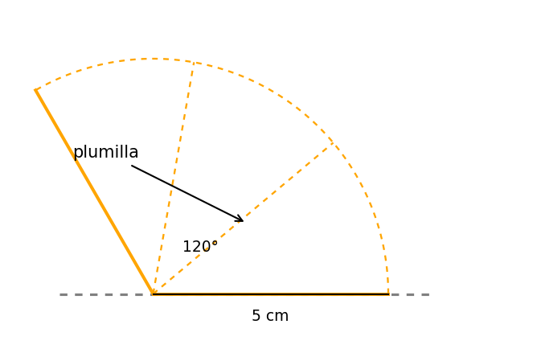

El esquema que representa los datos de las dimensiones del vitrina es:

## Answerlist

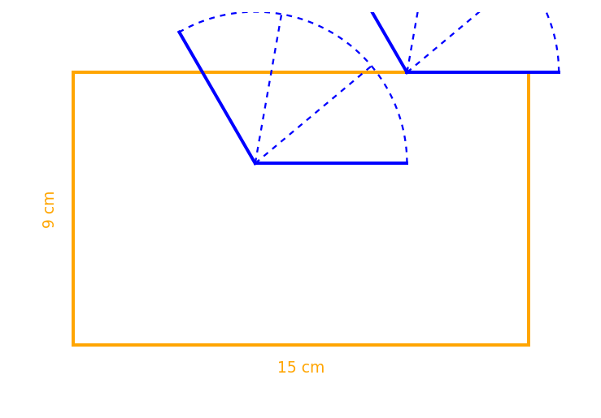

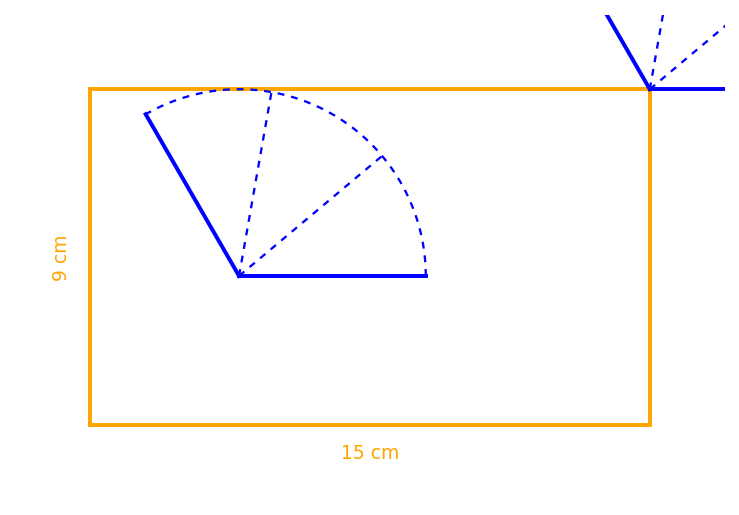

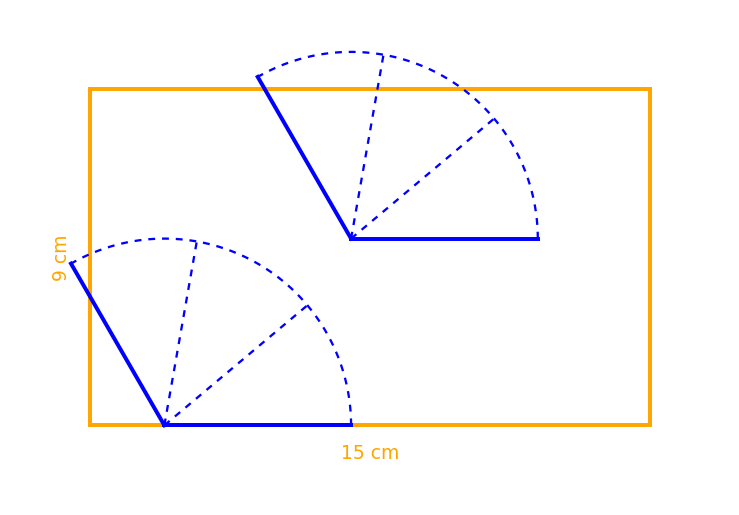

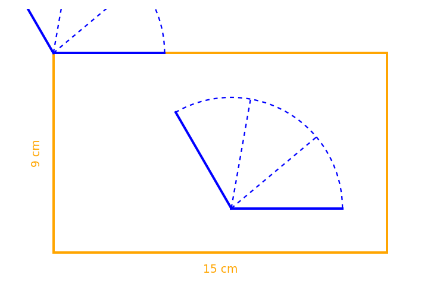

# Solution

La respuesta correcta es la opción A.

Para resolver este problema, debemos entender cómo funcionan los plumillas en el vitrina plano con forma de rectángulo. El vitrina tiene dimensiones de 15 cm × 9 cm, y cada plumilla tiene una longitud de 5 cm con un ángulo de apertura de 120°.

Por lo tanto, la opción A es la que mejor representa la configuración correcta para las dimensiones dadas.

## Answerlist

- Verdadero
- Falso
- Falso
- Falso

# Meta-information

exname: parabrisa_limpiaparabrisas_v1 extype: schoice exsolution: 1000 exshuffle: TRUE exsection: Geometría|Aplicaciones geométricas